# Project 2 Draft - Classroom to Career

The classification problem this project aims to solve is predicting whether a student will receive a job offer after graduation. This prediction is based on many factors such as internships and projects completed, certifications, and soft or networking skills.

By analyzing the effects of these factors, we can address questions like: How can students maximize their time during university? Which skills and experiences are the most impactful in securing a job offer after graduation? Having awareness in these topics can be extremely valuable to college students in preparing for the work force.

The dataset used for this project was found on Kraggle: [Education and Career Success](https://www.kaggle.com/datasets/adilshamim8/education-and-career-success)

This dataset covers a variety of different factors that might influence the number of job offers a student recieves across 5000 rows. The 20 columns fall into categories like student information, academic performance, skills & extracurricular activities, and career outcomes. The career outcomes includes job offers, starting salary, career satification, years to promotion, and more. This project will focus on the job offers recieved after graduation.

**Target Attribute**:  
Job_Offers - Number of job offers received after graduation (0-5)

**Valuable Attributes**:

- Age – Age of the student (18-30 years)
- Gender – Male, Female, or Other
- Internships_Completed – Number of internships completed (0-4)
- Projects_Completed – Number of personal/academic projects completed (0-9)
- Certifications – Number of additional certifications earned (0-5)
- Soft_Skills_Score – Soft skills rating (1-10)
- Networking_Score – Score based on professional networking and connections (1-10)

**Pre-processing the data** 5pts

What pre-processing steps do you follow? Explain why you do each pre-processing step.

```python
!pip install scikit-learn
```

```python
import pandas as pd # for working with data
import numpy as np # for working with data
import seaborn as sns # for making visualizations
from matplotlib import pyplot as plt # for making visualizations
from sklearn.model_selection import train_test_split
```

```python
career_df = pd.read_csv('education_career_success.csv')
```

```python
career_df.shape
```

```
(5000, 20)
```

```python
career_df.columns
```

```
Index(['Student_ID', 'Age', 'Gender', 'High_School_GPA', 'SAT_Score',
       'University_Ranking', 'University_GPA', 'Field_of_Study',
       'Internships_Completed', 'Projects_Completed', 'Certifications',
       'Soft_Skills_Score', 'Networking_Score', 'Job_Offers',
       'Starting_Salary', 'Career_Satisfaction', 'Years_to_Promotion',
       'Current_Job_Level', 'Work_Life_Balance', 'Entrepreneurship'],
      dtype='object')
```

```python
career_df.isna().sum()
```

```
Student_ID               0
Age                      0
Gender                   0
High_School_GPA          0
SAT_Score                0
University_Ranking       0
University_GPA           0
Field_of_Study           0
Internships_Completed    0
Projects_Completed       0
Certifications           0
Soft_Skills_Score        0
Networking_Score         0
Job_Offers               0
Starting_Salary          0
Career_Satisfaction      0
Years_to_Promotion       0
Current_Job_Level        0
Work_Life_Balance        0
Entrepreneurship         0
dtype: int64
```

```python
career_df.dtypes
```

```
Student_ID                object
Age                        int64
Gender                    object
High_School_GPA          float64
SAT_Score                  int64
University_Ranking         int64
University_GPA           float64
Field_of_Study            object
Internships_Completed      int64
Projects_Completed         int64
Certifications             int64
Soft_Skills_Score          int64
Networking_Score           int64
Job_Offers                 int64
Starting_Salary          float64
Career_Satisfaction        int64
Years_to_Promotion         int64
Current_Job_Level         object
Work_Life_Balance          int64
Entrepreneurship          object
dtype: object
```

```python
career_df['Gender'].value_counts()
```

```
Gender
Male      2458
Female    2350
Other      192
Name: count, dtype: int64
```

```python
career_df['Field_of_Study'].value_counts()
```

```
Field_of_Study
Arts                749
Mathematics         745
Law                 727
Business            719
Engineering         701
Medicine            689
Computer Science    670
Name: count, dtype: int64
```

```python
career_df = pd.get_dummies(career_df, columns = ['Gender', 'Field_of_Study'])
```

```python
career_df.shape
```

```
(5000, 28)
```

Now I am check if the data is balanced. And I can see slight changes in each number category but it is very balanced. All within the 804 <= x <= 856

```python
career_df['Job_Offers'].value_counts()
```

```
Job_Offers
2    856
0    848
5    843
3    826
1    823
4    804
Name: count, dtype: int64
```

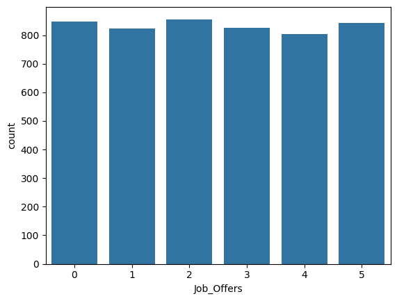

```python
sns.countplot(data=career_df, x='Job_Offers')
```

However, since we want to make this a classification problem. I will remove rows with job_offers greater than 1. This would make our problem statement be determining what factors lead to students getting at least one job offer.

```python
career_df = career_df[career_df['Job_Offers'] <= 1]
```

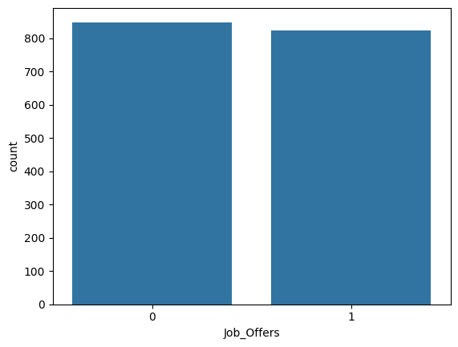

```python
sns.countplot(data=career_df, x='Job_Offers')
```

**Data Understanding/Visualization** 5pts

Use methods to try to further understand and visualize the data. Make sure to remember your initial problems/questions when completing this step. While exploring, does anything else stand out to you (perhaps any surprising insights?)

- How does this step relate to your modeling?

**Modeling** 20pts

What model(s) do you use to try to solve your problem? Why do you choose those model(s)?

Briefly explain each algorithm used (what is it, how does it work, pros/cons, etc.).

```python
X = career_df.drop(columns=['Job_Offers'])
y = career_df['Job_Offers']
```

```python
X_train, X_test, y_train, y_test = train_test_split(X, y, test_size=0.5)
```

```python
X_train.shape, y_train.shape, X_test.shape, y_test.shape
```

[output not shown]

**Evaluation** 15pts

How well does your model(s) perform? What evaluation metrics do you use and why?

**Storytelling** 10pts

What have you learned? Tell a story around your data (insights gained through modeling). Were you able to answer your initial problems/questions (if so, discuss that)?

**Impact Section** 5pts

Discuss the possible impact of your project. This can be socially, ethically, etc. It cannot be something like "our project has no impact" or "our project has no negative impact." Even the most well-intentioned projects *could* have a negative impact.